# Spatial Analytics Technical Project

# 1. Importing Libraries

Loading the following libraries which are needed to run the code.

```r
library(sf)
library(tidyverse)
library(tmap)
```

# 2. Loading data

Loading the two data sets *Shark_attacks.csv* and *au.csv*.

```r
shark_attacks <- read.csv(file = "../data/shark_attacks.csv", sep = ";") # Loading as a CSV file
au_pop <- read.csv("../data/au.csv") # Loading as a CSV file
```

Loading the shape files for the map of Australia and for Australian States.

```r
world_shape<- read_sf("../data/ne_50m_admin_0_countries/ne_50m_admin_0_countries.shp") # Loading world map
australia_shape <- world_shape[world_shape$SOVEREIGNT == "Australia",] # Filtering only to get rows that contain Australia


australia_states <- read_sf("../data/australia_Map/STE_2021_AUST_GDA2020.shp") # Loading the shape file for Australia States
```

# 3. Data Cleaning

Cleaning the data for analysis.

Replacing commas to full stops in latitude and longitude columns. This is done in order to make it a sf object.

```r
columns <- c("Latitude", "Longitude") # The two columns that need cleaning.
shark_attacks[columns] <- lapply(shark_attacks[columns], gsub, pattern = ",", replacement = ".") # For every row in the columns
# Replace comma with full stop.
```

The column **Longitude** contains empty spaces which need to be removed. And the two columns longitude and latitude are currently character columns they need to be numeric columns.

```r
shark_attacks <- shark_attacks[!(shark_attacks$Longitude == ""), ] # Removing empty spaces
shark_attacks <- shark_attacks %>% mutate_at(c('Longitude', 'Latitude'), as.numeric) # Transforming column type
```

After transforming, the columns contain NA values that need to be removed.

```r
shark_attacks_clean <- shark_attacks %>% drop_na(Latitude) # Removing all NA values from Latitude column
shark_attacks_cleaned <- shark_attacks_clean %>% drop_na(Longitude) # Removing all NA values from longitude column
```

The column **Victim.injury** in the Shark Attack data set has values that are the same, but spelled differently. They need to be grouped together.

```r
shark_attacks_cleaned$Victim.injury <- ifelse(shark_attacks_cleaned$Victim.injury %in% c("injured", "Injured", "injury"), "injured", shark_attacks_cleaned$Victim.injury) # Renaming differently spelled words to be the same word.
```

The Australia shape file, and the State shape files have rows that I do not need.

```r
australia_shape <- australia_shape[-3,] # Removing third row, which is Heard Island and McDonald Islands.
australia_states <- australia_states[-10,] # Removing tenth row which is not a State.
```

# 4. Spatial transformation

Now that the data sets are cleaned, I can begin spatial transformation. The first step is to make them into SF objects and transform the CRS.

```r
au_pop_crs <- st_as_sf(au_pop, coords = c("lng", "lat"), crs = 4326) # Creating SF object with CRS 4326
shark_attacks_crs <- st_as_sf(shark_attacks_cleaned, coords = c("Longitude", "Latitude"), crs = st_crs(4326) )# Creating SF object with
# CRS 4326

au_pop_crs <- st_transform(au_pop_crs, crs = 3112) # Transforming the CRS to Australia's CRS
shark_attacks_crs <- st_transform(shark_attacks_crs, crs = 3112) # Transforming the CRS to Australia's CRS
```

Currently, the Australia SF object is a MULTIPOLYON. I want it to be a POLYGON To make it a POLYGON, I first need to unionize the strings and than cast it to a POLYGON.

```r
australia_shape <- st_cast(australia_shape, "MULTILINESTRING") # SF object to MULTILINESTRING
australia_shape_union <- st_union(australia_shape) # Unionizing all geometries to one.
australia_shape_polygon <- st_cast(australia_shape_union, "POLYGON") # Casting to a polygon
```

The Australia shape and States are already SF objects, but currently have the wrong CRS.

```r
australia_shape_polygon_crs <- st_transform(australia_shape_polygon, crs = 3112) # Transforming CRS to Australia CRS
australia_states_crs <- st_transform(australia_states, crs = 3112) # Transforming CRS to Australia CRS
```

# 5. Spatial manipulation

## 5.1 Creating buffer

Now that my Australia shape has the correct CRS, I want to create a inverse buffer in order to only have cities located close to the coast.

```r
australia_shape_buffer <- st_buffer(australia_shape_polygon_crs, dist = -100000) # Creating an inverse buffer of 100 km.
```

## 5.1.2 Buffer Plot

The plot below shows the buffer that is created (BLUE), and the map of Australia. I will select the cities that are located in the white line.

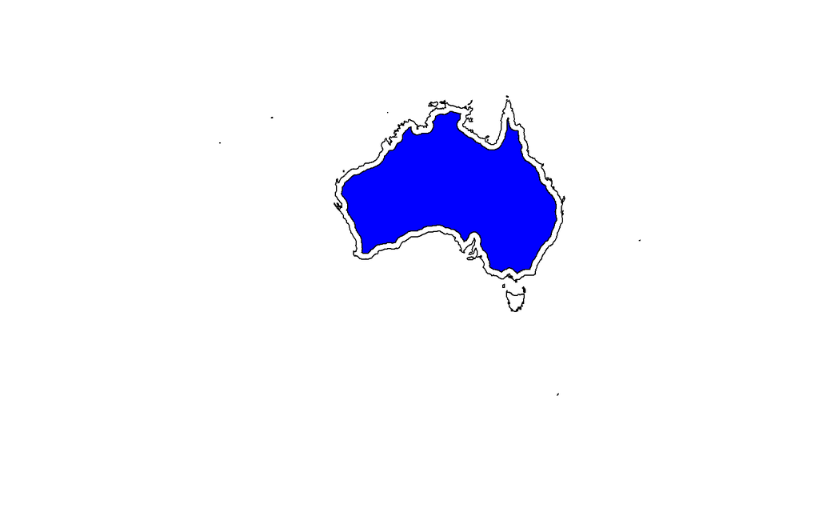

```r
plot(st_geometry(australia_shape_polygon_crs)) # Plotting Australia map
plot(st_geometry(australia_shape_buffer), col = "blue", add = TRUE) # Plotting the buffer on top of the map
```

## 5.1.3 Selecting coastal cities

After creating the buffer, I can now select the cities that do not intersect with the buffer. I start be checking if the CRS for my two SF objects are the same.

```r
st_crs(au_pop_crs) == st_crs(australia_shape_buffer) # Seeing if the CRS for the buffer and my city data is the same.
```

```
[1] TRUE
```

Then I created a new variable to store a Boolean. If the City intersects with the buffer it returns TRUE. It returns FALSE if the city does not intersect with the buffer.

```r
cities <- lengths(st_intersects(au_pop_crs, st_sf(australia_shape_buffer))) > 0 # Finding which cities intersect.
```

Selecting all cities that are FALSE. These are the cities that do not intersect with the buffer, and thereby the cities that are 100 km from the coast.

```r
costal_cities <- au_pop_crs[!cities,] # Selecting all cities that are false.
```

# 6. Visualisation

After cleaning the data, and making spatial transformation it is time to create visualizations. It will be using Tmap to create maps of the shark attacks in Australia, but I will also be using GGPLOT2 to create bar graphs and line graphs to better understand the data.

## 6.1 Attacks pr Year

The first visualization I will make is attacks pr year. This visualization is created to see the trend in shark attacks over 200 years. ### 6.1.1 Counting attacks The first step is to count the number of attacks pr year.

```r
shark_attack_year <- shark_attacks_crs %>% # Creating a pipe to count the number of Incidents pr year.
  count(Incident.year)
```

### 6.1.2 Plotting the attacks pr year

Now that I have counted the attacks pr year, I am going to create a line plot to show the trend in attacks pr year.

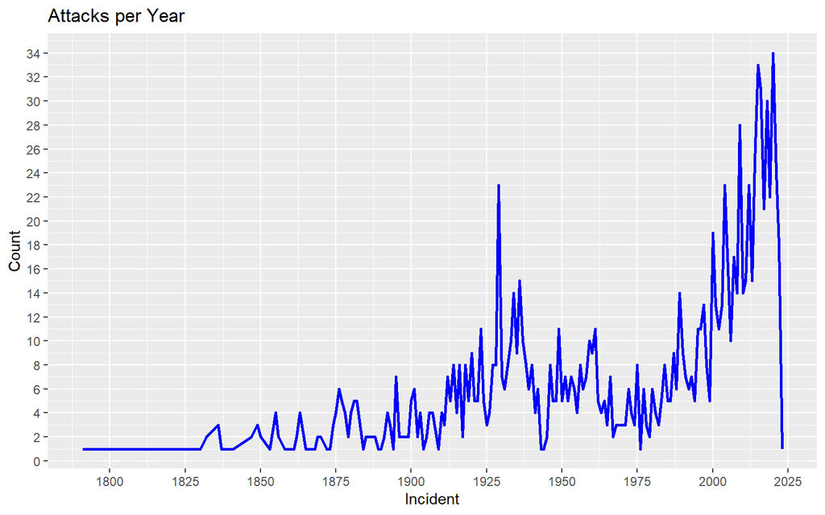

```r
ggplot(shark_attack_year, aes(Incident.year, n)) + # Using ggplot to plot count of incident.year
  geom_line(col= "blue", size = 1) + # Line color black
  labs(title = "Attacks per Year", # Title
       x = "Incident", # X axis title
       y = "Count") + # Y axis title
  scale_x_continuous(n.breaks = 10)+ # 10 breaks in x axis
  scale_y_continuous(n.breaks = 20) # 20 breaks in y axis
```

```r
ggsave(path = "../figs", filename = "Attacks_per_year.png") # Saving the plot to folder figs
```

The plot shows that there is an increase in attacks throughout the years. There is a spike in the year 1929, and most attacks occurred in 2020. This plot will be discussed in the adjoining paper.

## 6.2 Attacks per state

The next visualization I will make is the number of attacks per state. This is done to see which states have the most attacks. The first step is to count the attacks per state

```r
shark_attack_state <- shark_attacks_crs %>% # Creating a pipe
  group_by(State) %>% # Grouping the data frame by state
  count() # Counting how many times each state appears
```

After getting the count of each state, I can now plot it.

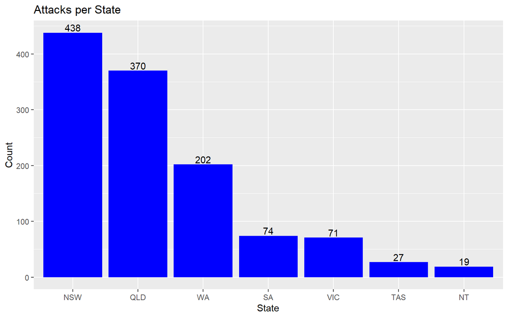

```r
ggplot(shark_attack_state, aes(reorder(State, -n), n)) + # Plotting the count, highest to lowest.
  geom_col(fill = "blue")+
  geom_text(aes(label = n), vjust = -0.2)+ # Adding label to each bar
  labs(title = "Attacks per State", # Title
       x = "State", # X axis title
       y = "Count")  # Y axis title
```

```r
ggsave(path = "../figs", filename = "Attacks_per_state.png") # Saving the plot to folder figs
```

Most attacks happened in the states of New South Wales and Queensland. This visualization will be discussed in the adjoining paper.

## 6.3 Activity when attacked

Now I will look at which activity the victim was doing when attacked. The first step is to see all the unique values, to see if any are misspelled words.

```r
unique(shark_attacks_crs$Victim.activity)
```

```
 [1] "swimming"                   "fishing"
 [3] ""                           "spearfishing"
 [5] "unmotorised boating"        "snorkelling"
 [7] "diving"                     "motorised boating"
 [9] "other: standing in water"   "boarding"
[11] "other:floating"             "other: hull scraping"
[13] "surfing"                    "other: jetskiing; swimming"
```

The values that start with **other** can be grouped together.

```r
shark_attack_activities <- shark_attacks_crs  # Creating a duplicate data frame.

# All values that start with other, and empty values will be renamed to other.
shark_attack_activities$Victim.activity <- ifelse(shark_attacks_crs$Victim.activity %in% c("other:floating", "other: standing in water", "other: hull scraping", "other: jetskiing; swimming", ""), "other", shark_attacks_crs$Victim.activity) #
```

After grouping some of the activities together, I can now count the occurrence of each activity.

```r
victim_activity_count <- shark_attack_activities %>%
  count(Victim.activity)
```

After counting it I can now plot it.

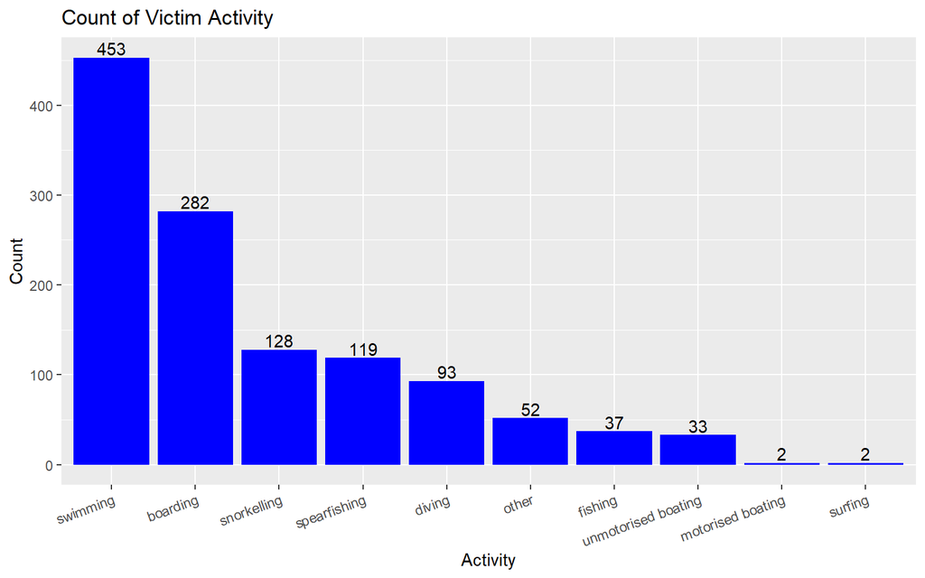

```r
ggplot(victim_activity_count, aes(reorder(Victim.activity, -n ), n))+ # Plotting activity by highest to lowest
  geom_col(fill = "blue")+ # It should be a bar plot
  geom_text(aes(label = n), vjust = -0.2)+ # Adding label to each bar
  labs(title = "Count of Victim Activity", # Title
       x = "Activity", # X axis title
       y = "Count")+ # Y axis title
  #scale_y_continuous(n.breaks = 10)+
  theme(axis.text.x = element_text(angle = 20, hjust = 1)) # Tilting the x axis labels.
```

```r
ggsave(path = "../figs", filename = "Activity_count.png") # Saving the plot to folder figs
```

Swimming is the activity with the most attacks. This visualization will be discussed in the adjoining paper.

## 6.4 Incidents per month and season

Now I want to find out which month has the most attacks. The first step is to count the occurrence of each month.

```r
attacks_pr_month <- shark_attacks_crs %>% # Creating pipe
  group_by(Incident.month) %>% # grouping by month
  count() # Counting occurrence of each month
```

Now I can plot it.

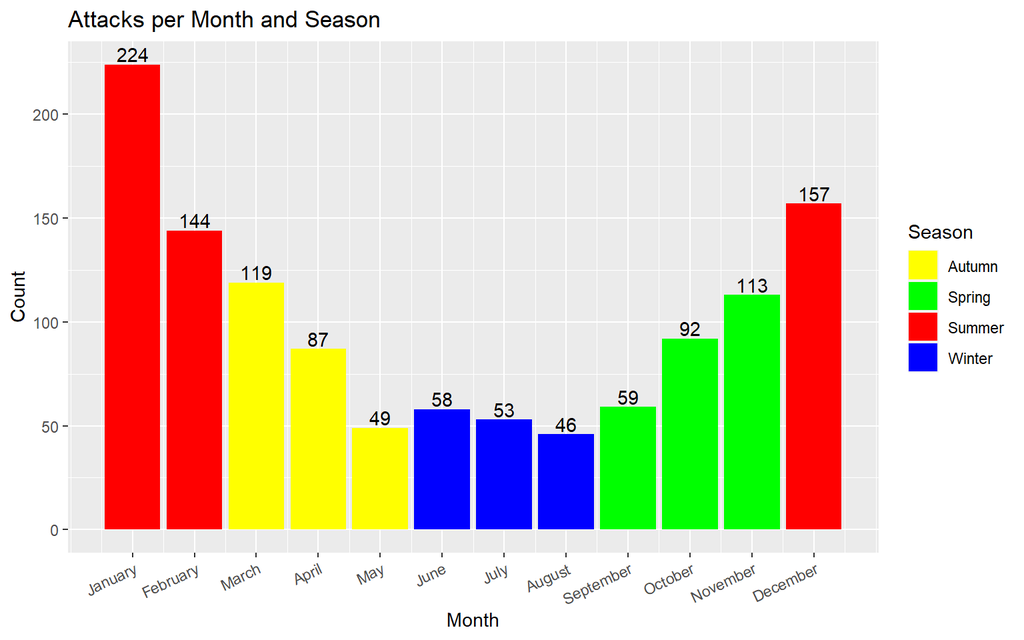

```r
# Creating a variable to be used in the plot, to help with coloring the plot.
monthly_colours = c("Summer", "Summer", "Autumn","Autumn","Autumn","Winter","Winter","Winter","Spring", "Spring", "Spring",  "Summer")


ggplot(attacks_pr_month, aes(Incident.month, n, fill = monthly_colours))+ # Creating plot with incident month and count.
  # Fill is the variable mounthly colors.
  geom_col()+ # It should be a bar plot
  geom_text(aes(label = n), vjust = -0.2)+ # Adding label to each bar
  scale_x_continuous(breaks = 1:12, labels = month.name[1:12])+ # Scaling x axis, and turning month from numbers to letters.
  theme(axis.text.x = element_text(angle = 25, hjust = 1))+ # Tilting the x axis labels
  labs(title = "Attacks per Month and Season",  # title
       x = "Month", y = "Count", # x axis title
       fill = "Season") + # Legend title
  scale_fill_manual(values = c("Summer" = "red", "Autumn" = "yellow", "Winter" = "blue", "Spring" = "green")) # Specifying colors
```

```r
ggsave(path = "../figs", filename = "Attacks_per_month_and_season.png") # Saving the plot to folder figs
```

The month with the most attacks is January, and the season with the most attacks is Summer. This will be discussed in the adjoining paper.

# 7. Plotting with Tmap

Now that I have done some initial ggplot plotting, I will start plotting with Tmap. ## 7.1 Plotting all attacks and costial cities The first plot I will make is all shark attacks in Australia, and the coastal cities.

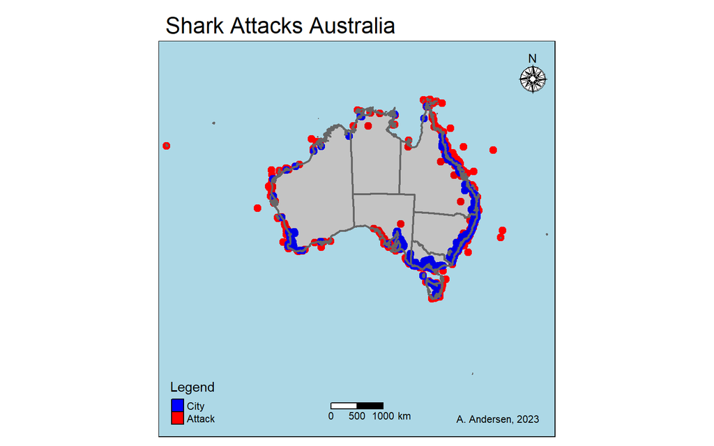

```r
tmap_mode("plot") # Setting map mode to plot.

australia_map <- tm_shape(australia_shape_polygon_crs)+ # Creating Australia shape  and saving in variable
  tm_polygons()

population_map <- tm_shape(costal_cities)+ # Creating coastal city shape.
  tm_dots(size = 0.3,
          col = "blue")

shark_map <- tm_shape(shark_attacks_crs)+ # Shark attacks as red dots
  tm_dots(size = 0.3, col = "red", title = "Shark attacks")

states <- tm_shape(australia_states_crs)+ # States as polygons
  tm_polygons(alpha = 0.1,
              col = "black",
              lwd = 2,
              title = "States")

scale_bar <- tm_scale_bar(breaks = c(0, 500, 1000), # Scale bar kilometers
                         text.size = 1,
                         position = c("LEFT", "bottom"))

compass <- tm_compass(position = c("RIGHT", "top"), # Compass
                      type = "rose",
                      size = 2 )

credits <- tm_credits(text = "A. Andersen, 2023") # Credits


layout <- tm_layout(main.title = "Shark Attacks Australia",
                   bg.color = "lightblue",
                   asp = 1) # Setting aspect ration of the map

legend <- tm_add_legend(type = "fill",
                        col = c("blue", "red"),
                        labels = c("City", "Attack"),
                        title = "Legend")

# combining it all together to make one map
shark_attacks_australia_map <- australia_map + shark_map  + population_map + states + layout + credits + scale_bar + compass + legend

shark_attacks_australia_map
```

```r
tmap_save(shark_attacks_australia_map, "../figs/shark_attacks_australia.png") # Saving the map in folder figs.
```

The map gives a good overview of where that attacks happened, and where the coastal cities are, but not much specific information can be extracted from the map.

## 7.2 Creating map with five most aggressive sharks.

```r
shark_type_count <- table(shark_attacks_crs$Shark.common.name) # Creating a table of number of attacks per species.
sort(shark_type_count) # Sorting the table
```

```
              blind shark                   dogfish        port jackson shark
                        1                         1                         1
             school shark           sevengill shark           silvertip shark
                        1                         1                         1
                  unknown broadnose sevengill shark       shortfin mako shark
                        1                         2                         2
          galapagos shark       blacktip reef shark               dusky shark
                        3                         4                         4
        hammerhead shark                lemon shark       whitetip reef shark
                        5                         5                         7
          grey reef shark          grey nurse shark       bronze whaler shark
                        8                         9                        27
                                       whaler shark                bull shark
                       53                        72                       200
                wobbegong               tiger shark               white shark
                      201                       229                       363
```

Creating a duplicate of the original data frame, so I do not mess up the data.

```r
shark_attack_count <- shark_attacks_crs # Creating duplicate.
```

All the sharks that are not the top five species will be renamed to **other**.

```r
shark_attack_count$Shark.common.name <- ifelse(shark_attack_count$Shark.common.name %in% c("blind shark", "dogfish", "port jackson shark", "school shark", "sevengill shark", "silvertip shark", "unknown", "broadnose sevengill shark", "shortfin mako shark", "galapagos shark", "blacktip reef shark", "dusky shark", "hammerhead shark ", "lemon shark", "whitetip reef shark", "grey reef shark", "grey nurse shark", "bronze whaler shark", "unknown", ""), "other", shark_attack_count$Shark.common.name)
```

### 7.2.2 Creating the plot

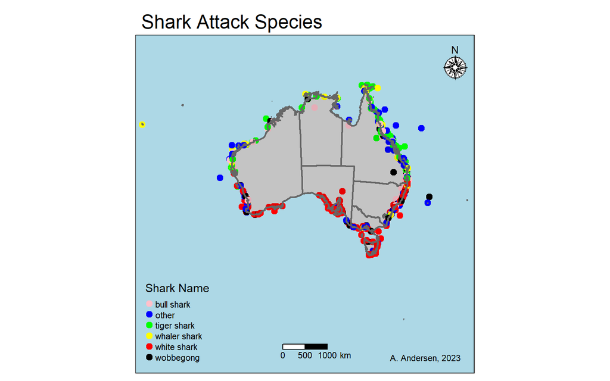

```r
tmap_mode("plot") # Setting the map mode to plot

australia_map <- tm_shape(australia_shape_polygon_crs)+  # Creating the shape of Australia
  tm_polygons()

shark_map <- tm_shape(shark_attack_count)+ # Plotting the attacks, with color set as shark type.
  tm_dots(size = 0.3, col = "Shark.common.name", palette=c("white shark" = "red", "tiger shark" = "green", "wobbegong" = "black", "bull shark" = "pink", "whaler shark" = "yellow", "other" = "blue"), title = "Shark Name")

states <- tm_shape(australia_states_crs)+ # Creating the states.
  tm_polygons(alpha = 0.1,
              col = "black",
              lwd = 2)

scale_bar <- tm_scale_bar(breaks = c(0, 500, 1000), # Scale bar kilometers
                         text.size = 1,
                         position = c("LEFT", "bottom"))

compass <- tm_compass(position = c("RIGHT", "top"), # Compass
                      type = "rose",
                      size = 2 )

credits <- tm_credits(text = "A. Andersen, 2023") # Credits

layout <- tm_layout(main.title = "Shark Attack Species", # Layout
                   bg.color = "lightblue",
                   asp = 1)

shark_attack_species_map <- australia_map + shark_map + states + scale_bar + compass + credits + layout # Combining into one map

shark_attack_species_map
```

```r
tmap_save(shark_attack_species_map, "../figs/shark_attack_species.png") # Saving the map in folder figs.
```

The created map shows how shark attacks by species depend on where you are. The south of Australia is dominated by White Sharks, while northern Australia has more species. This is further discussed in the adjoining paper.

## 7.3 Plotting states with most provoked and unprovoked attacks

Next, I will create a map of the states with the most provoked and unprovoked attacks. In order to do that, I first need to count the provoked and unprovoked attack for each state.

```r
provoked_unprovoked_count <- shark_attacks_crs %>% # Creating a pipe
  group_by(State, Provoked.unprovoked) %>% # Grouping by state and provoked.unprovoked
  count() %>% # counting each states provoked and unprovoked attacks.
  filter(Provoked.unprovoked != "") # Filtering out empty values
```

### 7.3.1 Ploting the count with ggplot

Before creating the Tmap, I will first create a bar plot. This will make it easier to see which state, has the most provoked and unprovoked attacks.

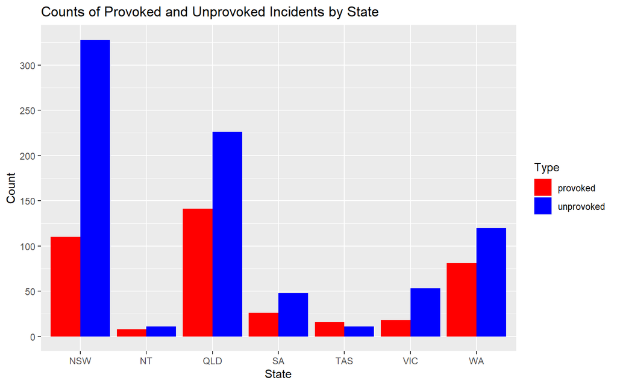

```r
ggplot(provoked_unprovoked_count, aes(State, n, fill = Provoked.unprovoked)) + # Plotting State and count.
  geom_col(position = "dodge")+ # Bar plot, with the columns side by side.
  labs(title = "Counts of Provoked and Unprovoked Incidents by State", # Title
       x = "State", # X axis title
       y = "Count", # Y axis title
       fill = "Type")+
  scale_fill_manual(values = c("provoked" = "red", "unprovoked" = "blue")) + # Setting colors for the legend.
  scale_y_continuous(n.breaks = 10) # Y Axis breaks
```

```r
ggsave(path = "../figs", filename = "Provoked_Unprovoked_per_State.png") # Saving the plot to folder figs
```

The bar graph shows that New South Wales and Queensland have the most provoked and unprovoked attacks. To see if there is a pattern in the attacks, I will plot the two states. ### 7.3.2 Plotting New South Wales and Queensland.

[figure not shown]

```r
new_south_wales_queensland <- australia_states_crs %>% # Filtering to only have rows of New South Wales and Queensland
  filter(STE_NAME21 %in% c("New South Wales", "Queensland"))

nsw_qld_shark_attacks <- shark_attacks_crs %>% # Filtering to only have rows of NSW and QLD
  filter(State == c("NSW", "QLD")) %>%
  filter(!(UIN %in% c(197, 1207, 198, 1025, 893, 1119, 1122, 1126))) # Excluding rows with missing data, or wrong location


tmap_mode("plot") # Tmap mode plot

shark_attack_nsw <- tm_shape(nsw_qld_shark_attacks)+ # Creating shape of shark attacks in the two states.
  tm_dots(size = 0.3, col = "Provoked.unprovoked", palette= c("provoked" = "red", "unprovoked" = "blue"), legend.show = TRUE, title = "Attack Type") # Specifying legend title and colors

nsw <- tm_shape(new_south_wales_queensland)+ # Map of New South Wales and Queensland.
  tm_polygons(alpha = 0.1,
              col = "black",
              lwd = 2)

layout <- tm_layout(main.title = "Shark Attacks in NSW and QLD", # Map title
                   bg.color = "lightblue") # Background color

scale_bar <- tm_scale_bar(breaks = c(0, 150, 300), # Scale bar
                         text.size = 1,
                         position = c("right", "bottom"))

nsw_qld_attacks <- shark_attack_nsw + nsw + layout + scale_bar + credits# Combining

nsw_qld_attacks
```

```r
tmap_save(nsw_qld_attacks, "../figs/shark_attack_type_nsw_qld.png") # Saving the map in folder figs.
```

It looks like that more provoked attacks happened in Queensland, whilst New South Wales is dominated by unprovoked attacks. This will be discussed in the adjoining paper.

## 7.4 Injury level pr state

The next visualization I will create is injury level by state. There are three levels. **Uninjured, Injured**, and **Fatal**. The first step is to count each injury occurrence pr state

```r
victim_injury_count <- shark_attacks_crs %>% # Creating pipe
  group_by(State, Victim.injury) %>% # Grouping by State and victim injury
  count() # Counting the injury per stat
```

Now that I have counted each injury per state I can plot it using ggplot.

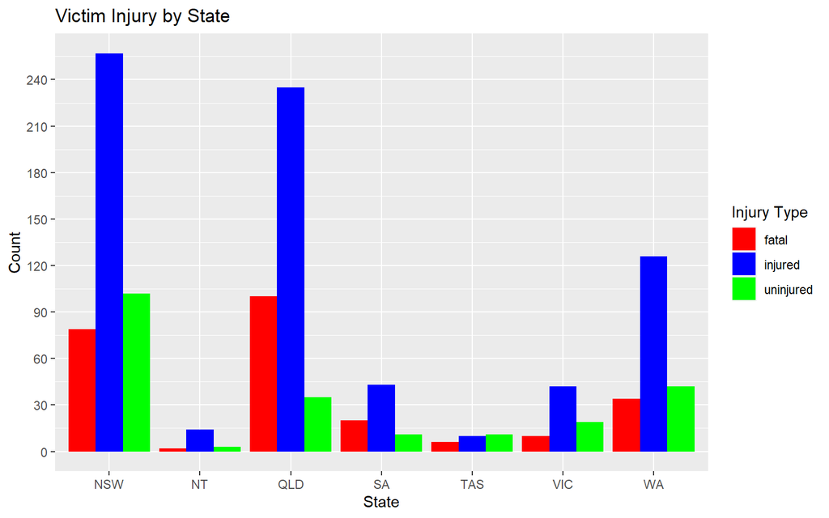

```r
ggplot(victim_injury_count, aes(State, n, fill = Victim.injury)) + # Plotting State and count, with fill set to injury type.
  geom_col(position = "dodge")+ # Columns should be next to each other
  labs(title = "Victim Injury by State", # Title
       x = "State", # X axis title
       y = "Count", # Y axis title
       fill = "Injury Type") + # Legend title
  scale_fill_manual(values = c("fatal" = "red", "injured" = "blue", "uninjured" = "green"))+ # Setting colors to injury type
  scale_y_continuous(n.breaks = 10) # 10 breaks in y axis
```

```r
ggsave(path = "../figs", filename = "Injury_per_state.png") # Saving the plot to folder figs
```

The state with the most injured is NSW, the state with the most uninjured is also NSW, but the state with the most fatal attacks is QLD.

### 7.4.1 Plotting Queensland Injuries.

To see where the injuries occurred, I will plot them on a map of the state of Queensland.

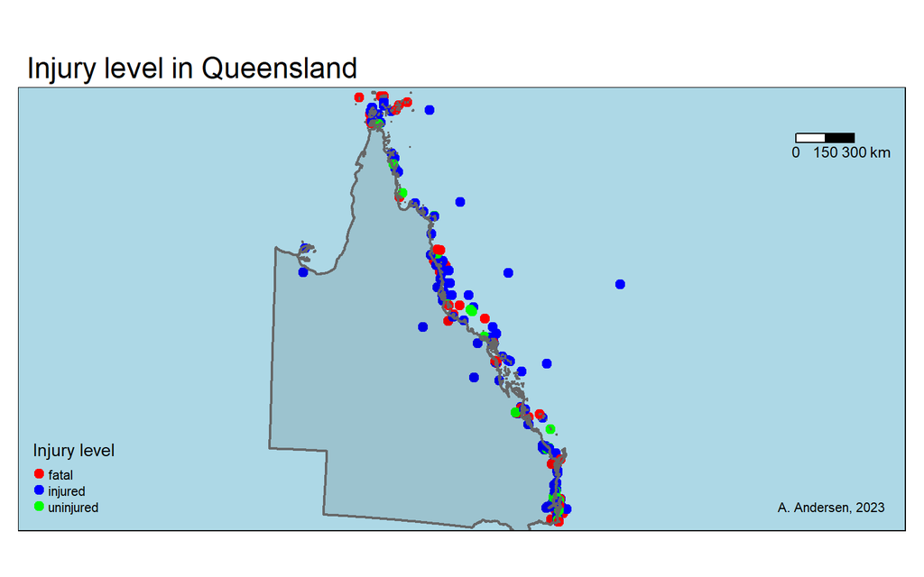

```r
queensland <- australia_states_crs %>% # Filtering to only have rows of Queensland
  filter(STE_NAME21 == c("Queensland"))

qld_shark_attacks <- shark_attacks_crs %>% # Filtering to only have rows of  QLD
  filter(State == c("QLD"))


tmap_mode("plot") # Tmap mode plot

shark_attack_qld <- tm_shape(qld_shark_attacks)+ # Creating shape of shark attacks in the two states.
  tm_dots(size = 0.3, col = "Victim.injury", palette= c("fatal" = "red", "uninjured" = "green", "injured" = "blue"), legend.show = TRUE, title = "Injury level") # Specifying legend title and colors

qld <- tm_shape(queensland)+ # Map of New South Wales and Queensland.
  tm_polygons(alpha = 0.1,
              col = "black",
              lwd = 2)

layout <- tm_layout(main.title = "Injury level in Queensland", # Map title
                   bg.color = "lightblue",# Background color
                   asp = 2)

scale_bar <- tm_scale_bar(breaks = c(0, 150, 300), # Scale bar
                         text.size = 1,
                         position = c("right", "top"))

qld_attacks <- shark_attack_qld + qld + layout + scale_bar + credits# Combining

qld_attacks
```

```r
tmap_save(qld_attacks, "../figs/Injuries_Queensland.png") # Saving the map in folder figs.
```